# Método Alejandro

Antonio Guillén Teruel

29/09/2021

```r
library(doParallel)
train.set <- read.csv("~/Alejandro/train_Alejandro.csv")
test.set <- read.csv("~/Alejandro/test_Alejandro.csv")
str(train.set)
```

```
'data.frame':   86367 obs. of  22 variables:
 $ Status  : Factor w/ 2 levels "Discharge","Expired": 1 1 1 1 1 1 1 1 1 1 ...
 $ Age     : int  41 20 89 44 45 42 47 49 60 56 ...
 $ Gender  : Factor w/ 2 levels "Female","Male": 2 2 1 1 2 1 1 2 2 1 ...
 $ NPC     : int  4 1 7 2 1 8 5 4 5 5 ...
 $ NSIST   : int  4 1 5 2 1 5 4 3 3 4 ...
 $ DM      : logi  FALSE FALSE TRUE FALSE FALSE FALSE ...
 $ IC      : logi  FALSE FALSE FALSE FALSE FALSE FALSE ...
 $ EPOC    : logi  FALSE FALSE FALSE FALSE FALSE FALSE ...
 $ HTA     : logi  FALSE FALSE TRUE FALSE FALSE FALSE ...
 $ DEP     : logi  FALSE FALSE FALSE FALSE FALSE FALSE ...
 $ VIH     : logi  FALSE FALSE FALSE FALSE FALSE FALSE ...
 $ CI      : logi  FALSE FALSE FALSE FALSE FALSE FALSE ...
 $ ACV     : logi  FALSE FALSE FALSE FALSE FALSE FALSE ...
 $ IRC     : logi  FALSE FALSE FALSE FALSE FALSE FALSE ...
 $ CIR     : logi  TRUE FALSE FALSE FALSE FALSE FALSE ...
 $ OST     : logi  FALSE FALSE FALSE FALSE FALSE FALSE ...
 $ ARTROSIS: logi  FALSE FALSE TRUE FALSE FALSE FALSE ...
 $ ARTRITIS: logi  FALSE FALSE FALSE FALSE FALSE FALSE ...
 $ DEM     : logi  FALSE FALSE FALSE FALSE FALSE FALSE ...
 $ DC      : logi  FALSE FALSE FALSE FALSE FALSE FALSE ...
 $ Obesity : int  0 0 0 0 0 0 0 0 0 0 ...
 $ Asthma  : int  0 0 0 0 1 0 0 1 0 0 ...
```

```r
str(test.set)
```

```
'data.frame':   500 obs. of  22 variables:
 $ Status  : Factor w/ 2 levels "Discharge","Expired": 1 1 1 1 1 1 1 1 1 1 ...
 $ Age     : int  64 46 51 81 33 32 45 42 49 6 ...
 $ Gender  : Factor w/ 2 levels "Female","Male": 1 2 2 2 1 1 1 2 2 2 ...
 $ NPC     : int  4 0 4 14 5 1 4 1 3 0 ...
 $ NSIST   : int  4 0 2 5 5 1 3 1 2 0 ...
 $ DM      : logi  FALSE FALSE TRUE FALSE FALSE FALSE ...
 $ IC      : logi  FALSE FALSE FALSE FALSE FALSE FALSE ...
 $ EPOC    : logi  FALSE FALSE FALSE FALSE FALSE FALSE ...
 $ HTA     : logi  TRUE FALSE FALSE TRUE TRUE FALSE ...
 $ DEP     : logi  FALSE FALSE FALSE FALSE FALSE FALSE ...
 $ VIH     : logi  FALSE FALSE FALSE FALSE FALSE FALSE ...
 $ CI      : logi  FALSE FALSE FALSE TRUE FALSE FALSE ...
 $ ACV     : logi  FALSE FALSE FALSE TRUE FALSE FALSE ...
 $ IRC     : logi  FALSE FALSE FALSE FALSE FALSE FALSE ...
 $ CIR     : logi  FALSE FALSE FALSE FALSE FALSE FALSE ...
 $ OST     : logi  FALSE FALSE FALSE FALSE FALSE FALSE ...
 $ ARTROSIS: logi  FALSE FALSE FALSE FALSE FALSE FALSE ...
 $ ARTRITIS: logi  FALSE FALSE FALSE FALSE FALSE FALSE ...
 $ DEM     : logi  FALSE FALSE FALSE FALSE FALSE FALSE ...
 $ DC      : logi  FALSE FALSE FALSE FALSE FALSE FALSE ...
 $ Obesity : int  0 0 1 1 0 0 0 0 0 0 ...
 $ Asthma  : int  0 0 0 1 0 0 0 0 0 0 ...
```

# 1 Preprocesamiento

```r
library(DataExplorer)
library(dplyr)
library(pROC)
library(caret)
ind.comorbilidades <- which(names(train.set)=="DM"):which(names(train.set)=="Asthma")
train.set <- train.set %>%
  update_columns(ind.comorbilidades, function(x){
    recode(as.integer(x),"0"="NO", "1"="SI")
  })
test.set <- test.set %>%
  update_columns(ind.comorbilidades, function(x){
    recode(as.integer(x),"0"="NO", "1"="SI")
  })
for(i in ind.comorbilidades){

  train.set[,i] <- as.factor(train.set[, i])
  test.set[,i] <- as.factor(test.set[, i])
}
```

# 2 Aplicando el método ‘pSubsets’

```r
library(dplyr)
discharge <- train.set %>% dplyr::filter(Status == "Discharge")
nrow(discharge)
```

```
[1] 85476
```

```r
expired <- train.set %>% filter(Status == "Expired")
nrow(expired)
```

```
[1] 891
```

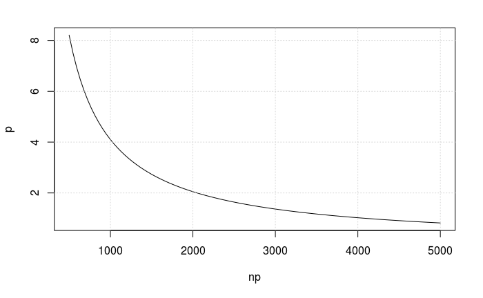

```r
curve(log(.01)/(log(1-1/891)*np), from = 500, to = 5000, xname = "np", ylab = "p")
grid()
```

En cada partición estarán un 75% del número de observaciones totales de la clase minoritaria del conjunto de train.

```r
log(.01)/(log(1-1/891)*669)
```

```
[1] 6.129901
```

Por tanto, bastará coger $p=7$.

```r
prop.mayoritaria<-0.55
set.seed(40)
p <- 7
np <- 669
dfs <- list()
# Seleccionamos todos los pacientes sanos que usaremos, y los reordenamos
id.dis <- sample(sample(x = 1:nrow(discharge), size = p*round(np*prop.mayoritaria/(1-prop.mayoritaria))), size = p*round(np*prop.mayoritaria/(1-prop.mayoritaria)))
for(k in 1:p){
  id.ex <- sample(x = 1:nrow(expired), size = np, replace = TRUE)
  dfs[[k]] <- rbind(discharge[id.dis[1:round(np*prop.mayoritaria/(1-prop.mayoritaria)) + round(np*prop.mayoritaria/(1-prop.mayoritaria))*(k-1)],],expired[id.ex,])
}
```

```r
unique(unlist(lapply(dfs,dim)))
```

```
[1] 1487   22
```

```r
unique(lapply(dfs,function(x) prop.table(table(x$Status))))
```

```
[[1]]

Discharge   Expired
0.5501009 0.4498991
```

# 3 Desarrollo de modelos

Usaremos `KAPPA` como métrica para estimar cómo de bien se ajustan los modelos que desarrollaremos a los datos que tenemos. Además, también calcularemos el *accuracy*, la *sensibilidad*, la *especificidad* y los valores predictivos positivos y negativos de cada modelo:

```r
metricas <- function(data, lev = levels(as.factor(data$obs)), model = NULL){
  c(
    ACCURACY = MLmetrics::Accuracy(data[, "pred"], data[, "obs"]),
    SENS = sensitivity(data[, "pred"],data[, "obs"],positive="Expired",negative="Discharge"),
    SPEC = specificity(data[, "pred"], data[, "obs"],positive="Expired",negative="Discharge"),
    PPV = posPredValue(data[, "pred"], data[, "obs"],positive="Expired",negative="Discharge"),
    NPV = negPredValue(data[, "pred"], data[, "obs"],positive="Expired",negative="Discharge"),
    KAPPA = psych::cohen.kappa(cbind(data[, "obs"],data[, "pred"]))$kappa,
    BAL_ACC = (sensitivity(data[, "pred"],data[, "obs"],positive="Expired",negative="Discharge") + specificity(data[, "pred"], data[, "obs"],positive="Expired",negative="Discharge"))/2
  )
}
```

Estas son las combinaciones de hiperparámetros que usaremos para entrenar nuestros modelos:

```r
hiperparametros <- expand.grid(
  mtry = 0:6*3+1,
  min.node.size = 1:3*10-9,
  splitrule = "gini"
)
hiperparametros
```

| mtry | min.node.size | splitrule |
| --- | --- | --- |
| 1 | 1 | gini |
| 4 | 1 | gini |
| 7 | 1 | gini |
| 10 | 1 | gini |
| 13 | 1 | gini |
| 16 | 1 | gini |
| 19 | 1 | gini |
| 1 | 11 | gini |
| 4 | 11 | gini |
| 7 | 11 | gini |

[output cut: 11 more lines]

Función para realizar la predicción:

```r
prediccion <- function(ensemble, x, q = 0.75){
  pred <- data.frame(matrix(nrow=nrow(x),ncol=0))
  for(modelo in ensemble) pred <- cbind(pred, predict(modelo,x))
  pred <- apply(pred, 1, function(x) prop.table(table(x))["Discharge"])
  ifelse(is.na(pred) | pred<q, "Expired", "Discharge")
}
```

Para obtener ‘b’:

```r
log(.01)/(log(1-1/669)*669)
```

```
[1] 4.601727
```

```r
b <- 5
```

Para $m_t$:

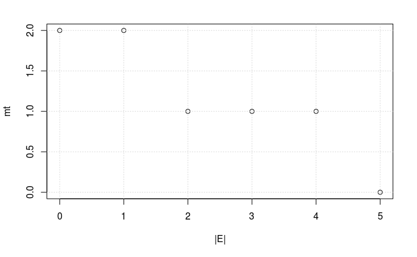

```r
mt <- function(n) { ceiling((b-n) / 3) }
plot(0:b, mt(0:b), xlab = "|E|", ylab = "mt")
grid()
```

Vamos a comenzar con el entrenamiento.

```r
E <- list() # Modelo final (ensemble de ensembles)
set.seed(123)

tC <- trainControl(
  summaryFunction = metricas,
  method = "cv",
  number = 5,
  allowParallel = TRUE,
  classProbs = TRUE
)
for(k in 1:p){
  Ek <- list() # Ensemble de modelos k-ésimo
  i <- 0 # Contador para el número de intentos de ampliar el ensemble
  # Conjunto de datos perfectamente balanceado:
  df <- dfs[[k]]
  while(length(Ek)<=b && i<mt(length(Ek))){
    # Seleccionamos muestras para entrenar el modelo de random forest
    no.ing <- which(df$Status == "Discharge")
    ing <- which(df$Status == "Expired")
    ind.train <- c(
      sample(no.ing, size = round(np*prop.mayoritaria/(1-prop.mayoritaria)), replace = TRUE),
      sample(ing, size = 669, replace = TRUE)
    )

    cl <- makeCluster(detectCores()-2)
    registerDoParallel(cl)

    rf <- train(
      x = df[ind.train,-1],
      num.trees = 200,
      importance = "impurity",
      y = df$Status[ind.train],
      method = "ranger",
      metric = "KAPPA",
      maximize = T,
      trControl = tC,
      tuneGrid = hiperparametros
    )

    stopCluster(cl)

    # Evaluamos el ensemble actual (sin el nuevo modelo)
    metricas.ensemble <-
      if (length(Ek)==0){
        u <- -Inf
        names(u) <- "KAPPA"
        u
      } else metricas(data.frame(
              obs = test.set$Status,
              pred= prediccion(Ek, test.set[-1])
           ))

    Ek[[length(Ek)+1]] <- rf
    # Evaluamos el ensemble formado al añadir el nuevo modelo
    metricas.ensemble.2 <- metricas(data.frame(
      obs = test.set$Status,
      pred= prediccion(Ek, test.set[-1])
    ))
    # Comparamos las metricas
    if(metricas.ensemble.2["KAPPA"] <= metricas.ensemble["KAPPA"]){ # Si el ensemble no mejora con el nuevo modelo...
      i <- i+1
      Ek[[length(Ek)]] <- NULL
    } else{ # En caso de ampliar el ensemble, reseteamos las oportunidades de cara a una nueva ampliación
      i <- 0
    }

  } # Fin del WHILE (hemos terminado de construir el ensemble k-ésimo)

  # Guardamos la información del ensemble k-ésimo
  E[[length(E)+1]] <- Ek

} # FIN. Hemos terminado de contruir el ensemble final

saveRDS(E,"~/Alejandro/Alejandro_Modelo1/Q1/Ensemble.669.7.kappa.rf.alejandro.0,9.rds")

E <- list() # Modelo final (ensemble de ensembles)
set.seed(12)

for(k in 1:p){
  Ek <- list() # Ensemble de modelos k-ésimo
  i <- 0 # Contador para el número de intentos de ampliar el ensemble
  # Conjunto de datos perfectamente balanceado:
  df <- dfs[[k]]

  while(length(Ek)<=b && i<mt(length(Ek))){
    # Seleccionamos muestras para entrenar el modelo de random forest
    no.ing <- which(df$Status == "Discharge")
    ing <- which(df$Status == "Expired")
    ind.train <- c(
      sample(no.ing, size = round(np*prop.mayoritaria/(1-prop.mayoritaria)), replace = TRUE),
      sample(ing, size = 669, replace = TRUE)
    )

    cl <- makeCluster(detectCores()-2)
    registerDoParallel(cl)

    rf <- train(Status ~ .,
                data = df[ind.train,],
      method = "glm",
      family = "binomial",
      maximize = T,
      metric = "KAPPA",
      trControl = tC
    )

    stopCluster(cl)

    # Evaluamos el ensemble actual (sin el nuevo modelo)
    metricas.ensemble <-
      if (length(Ek)==0){
        u <- -Inf
        names(u) <- "KAPPA"
        u
      } else metricas(data.frame(
              obs = test.set$Status,
              pred= prediccion(Ek, test.set[-1])
           ))

    Ek[[length(Ek)+1]] <- rf
    # Evaluamos el ensemble formado al añadir el nuevo modelo
    metricas.ensemble.2 <- metricas(data.frame(
      obs = test.set$Status,
      pred= prediccion(Ek, test.set[-1])
    ))
    # Comparamos las metricas
    if(metricas.ensemble.2["KAPPA"] <= metricas.ensemble["KAPPA"]){ # Si el ensemble no mejora con el nuevo modelo...
      i <- i+1
      Ek[[length(Ek)]] <- NULL
    } else{ # En caso de ampliar el ensemble, reseteamos las oportunidades de cara a una nueva ampliación
      i <- 0
    }

  } # Fin del WHILE (hemos terminado de construir el ensemble k-ésimo)

  # Guardamos la información del ensemble k-ésimo
  E[[length(E)+1]] <- Ek

} # FIN. Hemos terminado de contruir el ensemble final

saveRDS(E,"~/Alejandro/Alejandro_Modelo1/Q1/Ensemble.669.7.kappa.rlog.alejandro.0,9.rds")
```

# 4 Evaluamos el modelo

Cargamos el ensemble creado:

```r
ensemble <- readRDS("~/Alejandro/Alejandro_Modelo1/Q1/Ensemble.669.7.kappa.rf.alejandro.0,55.rds")
ensemble.rlog <- readRDS("~/Alejandro/Alejandro_Modelo1/Q1/Ensemble.669.7.kappa.rlog.alejandro.0,55.rds")
```

```r
unlist(lapply(ensemble,length))
```

```
[1] 3 2 4 2 2 3 2
```

```r
unlist(lapply(ensemble.rlog,length))
```

```
[1] 3 3 3 3 3 3 3
```

Función para realizar una predicción con el ensemble final.

```r
prediccion.final <- function(ensemble, x, q = 0.5){
  # Colocamos en cada fila de un conjunto de datos todas las predicciones para una muestra
    pred <- as.data.frame(lapply(ensemble, function(e) prediccion(e,x)))
  pred <- apply(pred, 1, function(x) prop.table(table(x))["Discharge"])
  ifelse(is.na(pred) | pred<q, "Expired", "Discharge")
}
```

Ahora podemos evaluar nuestro modelo final sobre el conjunto de test (balanceado) que hemos reservado:

```r
metricas.final.rf<- metricas(data.frame(
    obs = test.set$Status,
    pred= prediccion.final(ensemble, test.set[-1])
))
metricas.final.rlog<-metricas(data.frame(
    obs = test.set$Status,
    pred= prediccion.final(ensemble.rlog, test.set[-1])
))
```

[output not shown]

```r
metricas.final.rf
```

```
 ACCURACY      SENS      SPEC       PPV       NPV     KAPPA   BAL_ACC
0.9100000 0.9320000 0.8880000 0.8927203 0.9288703 0.8200000 0.9100000
```

```r
metricas.final.rlog
```

```
 ACCURACY      SENS      SPEC       PPV       NPV     KAPPA   BAL_ACC
0.9140000 0.9200000 0.9080000 0.9090909 0.9190283 0.8280000 0.9140000
```